# STAT 454 Project Progress Report 2

2024-04-23

## Research Goals

Analyze the evolution of space missions over time, such as changes in the frequency of missions, duration (hours in mission), and the shift from military to civilian astronauts. This could offer insights into how space exploration has evolved from the Cold War era to the present day. To answer the research question, we would like to concentrate on the mission time total taken based on related variables. Hierarchical modeling is a method that we first think of to tackle the task.

## Data Background

The dataset, meticulously compiled from various sources including NASA, Roscosmos, and enthusiast-driven websites, offers information of astronautical information. It encapsulates a wide array of data points ranging from the astronauts’ full names, gender, birth dates, and nationalities, to their military status and details regarding their selection programs. It is gathered and cleaned by a TidyTuesday contributor named Tom Mock.

### Display information about the dataset

```r
dim(astronauts)  # Number of rows and columns
```

```
## [1] 1277   24
```

```r
names(astronauts)  # First few rows
```

```
##  [1] "id"                       "number"
##  [3] "nationwide_number"        "name"
##  [5] "original_name"            "sex"
##  [7] "year_of_birth"            "nationality"
##  [9] "military_civilian"        "selection"
## [11] "year_of_selection"        "mission_number"
## [13] "total_number_of_missions" "occupation"
## [15] "year_of_mission"          "mission_title"
## [17] "ascend_shuttle"           "in_orbit"
## [19] "descend_shuttle"          "hours_mission"
## [21] "total_hrs_sum"            "field21"
## [23] "eva_hrs_mission"          "total_eva_hrs"
```

## Cleaning the Data

```
## # A tibble: 18 × 2
##    in_orbit         n
##    <chr>        <int>
##  1 STS            773
##  2 ISS            174
##  3 Soyuz           85
##  4 Mir             79
##  5 Salyut          61
##  6 Apollo          35
##  7 Gemini          20
##  8 Shenzhou        14
##  9 Skylab           7
## 10 explosion        7
## 11 Vostok           6
## 12 Voskhod          5
## 13 ASTP             3
## 14 MercuryAtlas     3
## 15 aborted          2
## 16 Euromir          1
## 17 MA               1
## 18 Spacehub         1
```

```
## [1] "Group 3" "Group 2" "Group 1"
```

```r
# Filter out rows with 0 hours_mission
astronauts <- astronauts %>%
  filter(hours_mission != 0)

# Log-transform the hours_mission variable
log_transformed_astronauts <- astronauts %>%
  mutate(log_hours_mission = log(hours_mission))  # Adding 1 to avoid log(0)
```

```r
model_h <- stan_glm(
  log_hours_mission ~ 1 + in_orbit_group, data = log_transformed_astronauts,
  family = gaussian,
  chains = 4, iter = 5000*2, seed = 84735, refresh = 0)
```

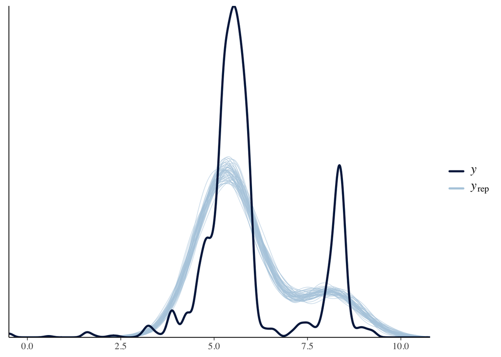

```r
pp_check(model_h)
```

```r
tidy(model_h, conf.int = TRUE, conf.level = 0.8)
```

```
## # A tibble: 3 × 5
##   term                  estimate std.error conf.low conf.high
##   <chr>                    <dbl>     <dbl>    <dbl>     <dbl>
## 1 (Intercept)               8.13    0.0483     8.07      8.19
## 2 in_orbit_groupGroup 2    -1.54    0.104     -1.67     -1.41
## 3 in_orbit_groupGroup 3    -2.83    0.0541    -2.90     -2.76
```

## Bibliography

https://juliasilge.com/blog/astronaut-missions-bagging/